# R Tutorial for CA 4: Central Limit Theorem

Authors: Leonore Findsen, Timothy Reese, Halin Shin, Jeremy Troisi STAT 350

# Generating observations from the sampling distribution of $\bar{X}$

In this assignment, you will explore the the implications of the Central Limit Theorem (CLT) on the distribution of $\bar{X}$ (sampling distribution for the mean) by generating samples of $\bar{X}$ from various population distributions and sample sizes $n$. It is advised to review key concepts such as *population, sample, sampling distribution,* and *Central Limit Theorem (CLT)* before beginning the tutorial.

## Example: Standard Normal Distribution

Let us assume $X \sim \text{Normal}(\mu=0, \sigma=1)$ and $\bar{X}$ is the sample mean statistic defined using $n=10$. We would like to generate a simple random sample of size 1500 of $\bar{X}$.

### Step 1

Define the numbers. Let SRS denote the total number of samples that will be taken from the distribution of $X$ and $n$ denote the sample size of each sample.

```r
SRS <- 1500
n <- 10
```

### Step 2

For **each one** of the 1500 observations of $\bar{X}$, we must first obtain $n$ observations from $X$ and take their sample mean. Thus a total of `SRS * n` observations must be made from $X$ first.

```r
data.vec <- rnorm(SRS * n)
```

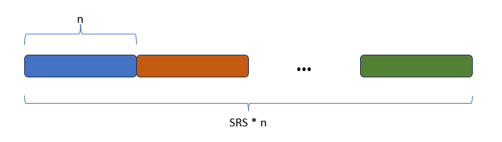

### Step 3

We now split up `data.vec` into 1500 sets each of size $n$.

```r
data.mat <- matrix(data.vec, nrow = SRS)
```

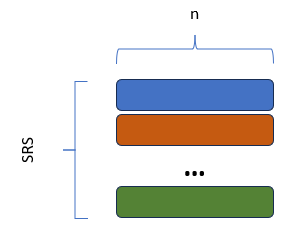

The `matrix` function takes a vector as the primary input along with a specification of `nrow` (# rows) and `ncol` (# columns). It then reorganizes the input into a matrix of dimension `nrow` $\times$ `ncol`. When the length of the input is a multiple of `nrow` or `ncol`, specifying one automatically determines the other. Each row of `data.mat` is now a size-$n$ sample of $X$.

### Step 4

Take the average of each row.

```r
avg <- apply(data.mat, MARGIN=1, FUN=mean)
```

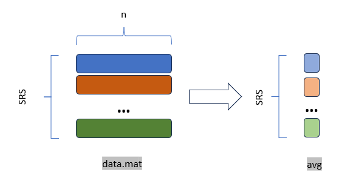

`apply` takes a matrix as the primary input and applies a vector function (`FUN`) separately on each row (`MARGIN=1`) or on each column (`MARGIN=2`). `avg` is our final output. It is a vector of length `SRS` obtained by applying `mean` on each row of `data.mat`. The resulting vector contains an SRS number of sample means from which we can find the experimental mean and experimental standard deviations.
$$\begin{pmatrix}
\bar{x}_1 \\
\bar{x}_2 \\
\vdots\\
\bar{x}_{SRS} \\
\end{pmatrix}$$

## Other distributions

To complete CA 4, you will be required to repeat the example above using other distributions and a range of choices for $n$. The specific list will be provided in the assignment.

To prevent confusion, it is recommended that you name the variables differently for each distribution (for example, `normal_data.vec`, `normal_data.mat` `normal_avg` for normal and `pois_data.vec`, `pois_data.mat`, `pois_avg` for Poisson).

Also, use `set.seed` to your advantage (see CA 3 tutorial). Additionally, refer back to plotting a histogram (see CA 2a tutorial) and plotting normal probability plots (see CA 3 tutorial).